# Telco Customer Churn Data Explanation

## Investigation Overview

In our investigation, we try to find different relationships between the Churn column and other columns. We want to know the characteristics of customers that leave the company to find solutions to make them change their minds.

## Dataset Overview

This data contains 7043 rows (customers) and 21 columns (features).

The data set includes information about:

- Customers who left within the last month – the column is called Churn
- Services that each customer has signed up for – phone, multiple lines, internet, online security, online backup, device protection, tech support, and streaming TV and movies
- Customer account information – how long they’ve been a customer, contract, payment method, paperless billing, monthly charges, and total charges
- Demographic info about customers – gender, age range, and if they have partners and dependents

## Churn Distribution

Data is imbalanced since customers who didn't leave in the last month represent 73.51%.

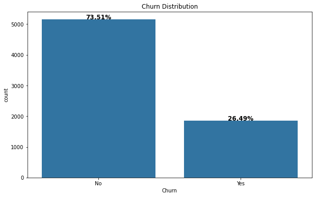

## SeniorCitizen Distribution by Churn

- 64.01 % of customers are young and don't leave the company.
- 19.71 % of customers are young and leave the company.
- 9.50 % of customers are senior citizens and don't leave the company.
- 6.78% of customers are senior citizens and leave the company.
- More than half of the customers are young and don't leave the company.
- We can't say most of the customers who don't leave the company are young. This is because the data is imbalanced since the number of young customers is greater than senior citizens. If the number of young customers and senior citizens is the same, It will be a fair comparison.

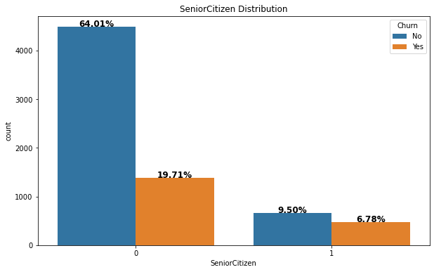

## Dependents Distribution by Churn

- 48.22% of customers don't have dependents and don't leave the company.
- 21.84% of customers don't have dependents and leave the company.
- 25.29% of customers have dependents and don't leave the company.
- 4.65% of customers have dependents and leave the company.
- About half of the customers don't have dependents and don't leave the company. And this is because most of the customers are young, and young people usually don't have dependents.

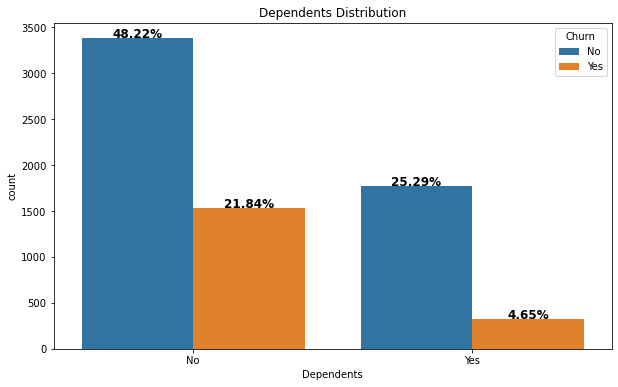

## Distribution of tenure vs SeniorCitizen and Churn

- Most young customers who leave the company don't stay more than 20 months with the company. It's the same for senior citizen customers.
- Regardless of was the customer is a young or senior citizen, the customers who stayed a few months are more likely to leave the company. And the customers who stayed for more than 35 months are more likely to stay with the company.

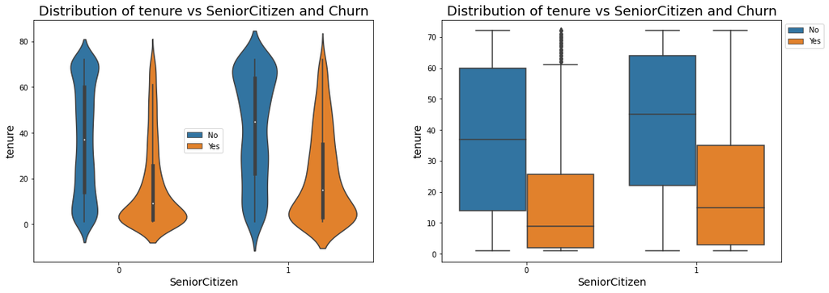

## Distribution of tenure vs InternetService and Churn

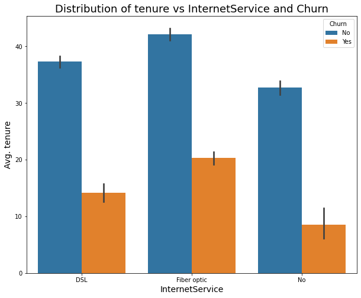